# HW_2 - Time Series Regression

### Model with Quarters(seasonality effect),Years, trend, lag1 and other variables

```r
lm_model_2=lm(UGS~trend+lag1+Quarter+RNUV+NLPG+PU+PG+NUGV+NDGV+GNPA+GNPC+GNPT+Years,UGSdata)
summary(lm_model_2)
```

```
##
## Call:
## lm(formula = UGS ~ trend + lag1 + Quarter + RNUV + NLPG + PU +
##     PG + NUGV + NDGV + GNPA + GNPC + GNPT + Years, data = UGSdata)
##
## Residuals:
##    Min     1Q Median     3Q    Max
## -38230  -9740   2424   7841  34696
##
## Coefficients: (1 not defined because of singularities)
##               Estimate Std. Error t value Pr(>|t|)
## (Intercept)  4.244e+06  1.187e+06   3.575  0.00382 **
## trend        1.629e+04  1.803e+04   0.903  0.38408
## lag1        -5.841e-01  2.375e-01  -2.459  0.03007 *
## QuarterQ2   -1.458e+04  6.458e+04  -0.226  0.82522
## QuarterQ3    2.940e+05  1.952e+05   1.506  0.15800
## QuarterQ4    1.429e+05  7.572e+04   1.887  0.08362 .
## RNUV         3.575e+06  1.989e+06   1.797  0.09752 .
## NLPG        -5.052e-01  2.295e-01  -2.201  0.04803 *
## PU           1.008e+03  1.169e+03   0.862  0.40548
## PG          -2.872e+03  1.805e+03  -1.591  0.13762
## NUGV        -1.199e+00  4.743e-01  -2.529  0.02649 *
## NDGV         1.379e+04  4.895e+03   2.817  0.01554 *
## GNPA        -3.553e-02  3.991e-02  -0.890  0.39083
## GNPC         1.475e-01  6.619e-02   2.228  0.04575 *
## GNPT        -1.350e-02  1.314e-02  -1.027  0.32458
## Years               NA         NA      NA       NA
## ---
## Signif. codes:  0 '***' 0.001 '**' 0.01 '*' 0.05 '.' 0.1 ' ' 1
##
## Residual standard error: 25860 on 12 degrees of freedom
##   (5 observations deleted due to missingness)
## Multiple R-squared:  0.9865, Adjusted R-squared:  0.9708
## F-statistic: 62.71 on 14 and 12 DF,  p-value: 5.179e-09
```

```r
tmp[,actual:=UGS]
tmp[,predicted_trend_quarter_vars:=predict(lm_model_2,tmp)]
tmp[,residual_trend_quarter_vars:=actual-predicted_trend_quarter_vars]
```

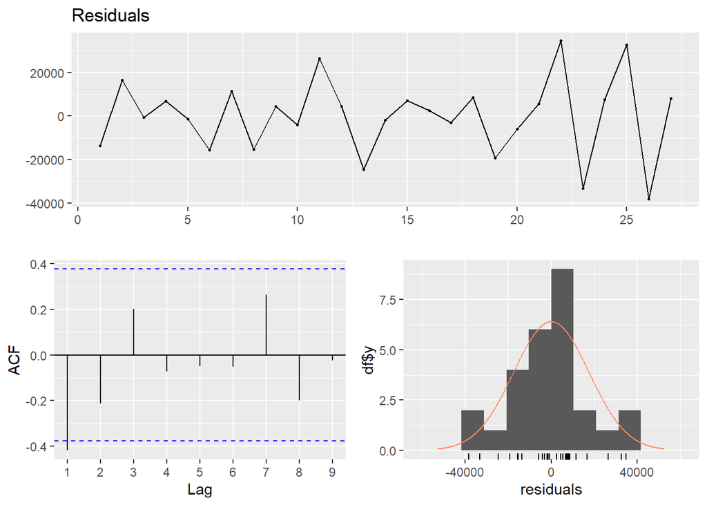

```r
require(forecast)
checkresiduals(lm_model_2$residuals)
```

Residual graphs of this model also shows us that autocorrelation decreased (lag 2,4,6,8 not high anymore) and residuals are closer to be with normality assumption in the last graph.

### Improved model of second model

First model was not good because of not enough predictors. Second model has good prediction power but with some extra updates on it, a better model can be obtained. As we can see on the summary of model_2, two variables “PU,GNPA,” are not significant for the model and also they have the highest p-value among insignificant variables. I will eliminate these two variables to see if it is better or not.

```r
lm_model_2=lm(UGS~trend+lag1+Quarter+RNUV+NLPG+PG+NUGV+NDGV+GNPC+GNPT+Years,UGSdata)
summary(lm_model_2)
```

```
##
## Call:
## lm(formula = UGS ~ trend + lag1 + Quarter + RNUV + NLPG + PG +
##     NUGV + NDGV + GNPC + GNPT + Years, data = UGSdata)
##
## Residuals:
##    Min     1Q Median     3Q    Max
## -36957 -10030   1753   8171  36605
##
## Coefficients: (1 not defined because of singularities)
##               Estimate Std. Error t value Pr(>|t|)
## (Intercept)  3.955e+06  1.083e+06   3.651 0.002618 **
## trend        7.074e+03  1.473e+04   0.480 0.638498
## lag1        -6.563e-01  2.132e-01  -3.079 0.008166 **
## QuarterQ2    2.753e+03  5.615e+04   0.049 0.961591
## QuarterQ3    2.017e+05  1.351e+05   1.493 0.157735
## QuarterQ4    1.655e+05  6.925e+04   2.390 0.031439 *
## RNUV         2.662e+06  1.715e+06   1.553 0.142836
## NLPG        -3.500e-01  1.607e-01  -2.177 0.047055 *
## PG          -1.214e+03  2.449e+02  -4.957 0.000211 ***
## NUGV        -1.076e+00  4.330e-01  -2.485 0.026195 *
## NDGV         1.267e+04  4.519e+03   2.804 0.014077 *
## GNPC         1.165e-01  5.478e-02   2.127 0.051652 .
## GNPT        -1.598e-02  1.174e-02  -1.361 0.195050
## Years               NA         NA      NA       NA
## ---
## Signif. codes:  0 '***' 0.001 '**' 0.01 '*' 0.05 '.' 0.1 ' ' 1
##
## Residual standard error: 24970 on 14 degrees of freedom
##   (5 observations deleted due to missingness)
## Multiple R-squared:  0.9853, Adjusted R-squared:  0.9728
## F-statistic: 78.39 on 12 and 14 DF,  p-value: 1.083e-10
```

```r
tmp[,actual:=UGS]
tmp[,predicted_trend_quarter_vars:=predict(lm_model_2,tmp)]
tmp[,residual_trend_quarter_vars:=actual-predicted_trend_quarter_vars]
```

As it can be seen in the above, adjusted R-squared increased to 0.9728 which is higher than previous model. Also, p-value decreased to 1.083e-10. Both are giving signs for improved model of 2. model is better one :)

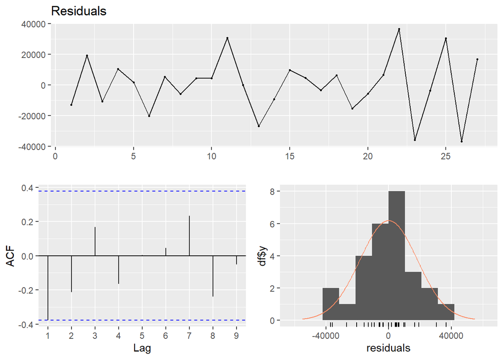

```r
require(forecast)
checkresiduals(lm_model_2$residuals)
```

## Selected Model

```r
lm_model_2=lm(UGS~trend+lag1+Quarter+RNUV+NLPG+PG+NUGV+NDGV+GNPC+GNPT+Years,UGSdata)
summary(lm_model_2)
```

```
##
## Call:
## lm(formula = UGS ~ trend + lag1 + Quarter + RNUV + NLPG + PG +
##     NUGV + NDGV + GNPC + GNPT + Years, data = UGSdata)
##
## Residuals:
##    Min     1Q Median     3Q    Max
## -36957 -10030   1753   8171  36605
##
## Coefficients: (1 not defined because of singularities)
##               Estimate Std. Error t value Pr(>|t|)
## (Intercept)  3.955e+06  1.083e+06   3.651 0.002618 **
## trend        7.074e+03  1.473e+04   0.480 0.638498
## lag1        -6.563e-01  2.132e-01  -3.079 0.008166 **
## QuarterQ2    2.753e+03  5.615e+04   0.049 0.961591
## QuarterQ3    2.017e+05  1.351e+05   1.493 0.157735
## QuarterQ4    1.655e+05  6.925e+04   2.390 0.031439 *
## RNUV         2.662e+06  1.715e+06   1.553 0.142836
## NLPG        -3.500e-01  1.607e-01  -2.177 0.047055 *
## PG          -1.214e+03  2.449e+02  -4.957 0.000211 ***
## NUGV        -1.076e+00  4.330e-01  -2.485 0.026195 *
## NDGV         1.267e+04  4.519e+03   2.804 0.014077 *
## GNPC         1.165e-01  5.478e-02   2.127 0.051652 .
## GNPT        -1.598e-02  1.174e-02  -1.361 0.195050
## Years               NA         NA      NA       NA
## ---
## Signif. codes:  0 '***' 0.001 '**' 0.01 '*' 0.05 '.' 0.1 ' ' 1
##
## Residual standard error: 24970 on 14 degrees of freedom
##   (5 observations deleted due to missingness)
## Multiple R-squared:  0.9853, Adjusted R-squared:  0.9728
## F-statistic: 78.39 on 12 and 14 DF,  p-value: 1.083e-10
```

```r
tmp[,actual:=UGS]
tmp[,predicted_trend_quarter_vars:=predict(lm_model_2,tmp)]
tmp[,residual_trend_quarter_vars:=actual-predicted_trend_quarter_vars]
```

```r
mean = mean(lm_model_2$residuals)
paste("residual mean:",mean)
```

```
## [1] "residual mean: 2.61190246385889e-13"
```

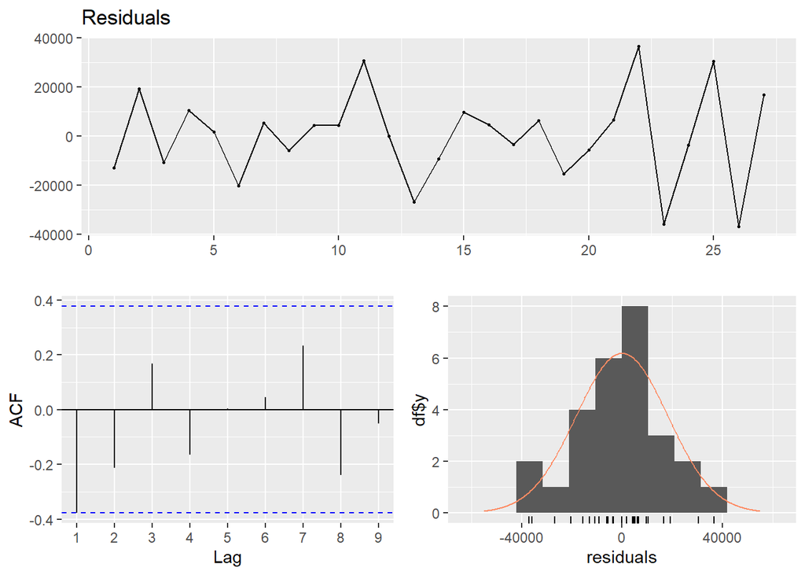

```r
checkresiduals(lm_model_2$residuals)
```

## 2007 Quarters Forecast

By using my last and best fitted model, I do forecasting of UGS value for four quarters of 2007. Here is the result:

As a result, I tried 3 different models. After doing some extractions on the second model, I gained a better model(third) which I used for forecasting 2007. This model has the lowest p-value, the highest adj. R squared value and the most proper residuals on assumptions.  
Here is the UGS sales predictions for year 2007:

```r
predc= UGSdata[29:32,c("trend","lag1","Quarter","RNUV","NLPG","PG","NUGV","NDGV","GNPC","GNPT","Years")]
prediction = c(0,0,0,0)
for(i in 1:4) {
  prediction[i] = predict(lm_model_2,newdata = predc[i,])
  if(i<4){predc[i+1,"lag1"] = prediction[i] }
}
prediction
```

```
## [1] 657576.3 871460.4 962913.4 817633.3
```